# Survival Analysis Sample Data Creation

Mick Cooney

28 Nov 2016

# 1 Create Example Survival Data

In this workbook we are going to generate a baseline hazard rate with a time-varying effect and then add some proportional hazards in addition to calculate some generated survival times. We will also add some censorship.

```r
N_dataset <- 10000

gender_dt <- data.table(gender      = c("M", "F")
                       ,gender_prop = c(0.65, 0.35)
                        )

health_dt <- data.table(health      = c("Unhealthy", "Average", "Healthy")
                       ,health_prop = c(        0.3,      0.55,      0.15)
                        )

early_rate <- 0.0180
late_rate  <- 0.0090


baseline_early <- rbeta(60, early_rate * 500, (1 - early_rate) * 500)
baseline_late  <- rbeta(60, late_rate  * 200, (1 - late_rate)  * 200)

baseline_hazard <- c(baseline_early, baseline_late)
baseline_hazard <- pmax(baseline_hazard, 0.0030)


gender_hazard <- 1.2
health_hazard <- c("Healthy" = 0.8, "Unhealthy" = 1.3)
age_hazard    <- function(age) 0.001 * age + 0.001 * age^2
```

Having determined the baseline hazard rate, we now create a plot of the hazards. We will look at both the instantaneous hazards and the cumulative survival rate.

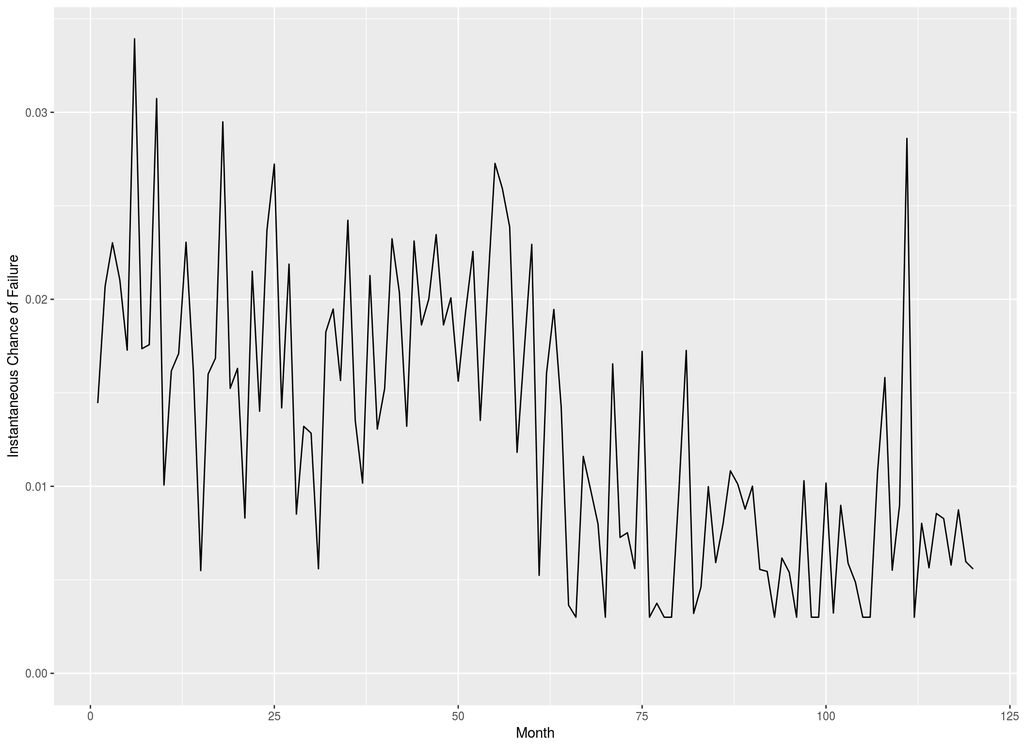

```r
ggplot() +
    geom_line(aes(x = seq_along(baseline_hazard), y = baseline_hazard)) +
    expand_limits(y = 0) +
    xlab("Month") +
    ylab("Instantaneous Chance of Failure")
```

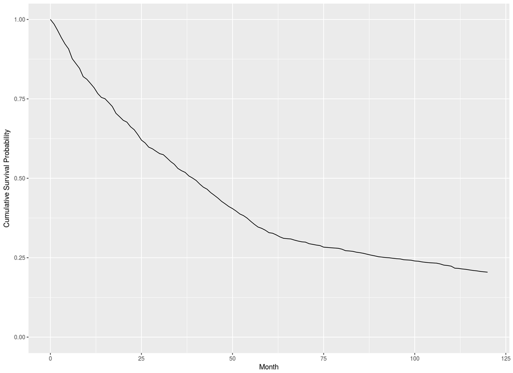

```r
ggplot() +
    geom_line(aes(x = c(0, seq_along(baseline_hazard))
                 ,y = cumprod(c(1, 1 - baseline_hazard)))) +
    expand_limits(y = 0) +
    xlab("Month") +
    ylab("Cumulative Survival Probability")
```

Now that we have set basic parameters to create the data, we now generate some data and generate failure times. We also uniformly generate observation times to ensure some of the values are censored.

```r
generate_fail_time <- function(probs) {
    fail_ids <- which(runif(length(probs) + 1, 0, 1) <= c(probs, 1))

    fail_ids[1]
}


# Generate covariate data and calculate the risk factors
sample_dt <- CJ(gender  = gender_dt$gender
               ,health = health_dt$health) %>%
    inner_join(gender_dt, by = 'gender') %>%
    inner_join(health_dt, by = 'health') %>%
    mutate(sample_prop = gender_prop * health_prop)

idx <- sample(1:nrow(sample_dt)
             ,size = N_dataset
             ,prob = sample_dt$sample_prop
             ,replace = TRUE)

data_dt <- sample_dt[idx] %>%
    mutate(age_at_start = round(rnorm(n(), 40, 10))
          ,rf_gender    = ifelse(gender == 'M', gender_hazard, 1)
          ,rf_health    = case_when(health == 'Average'   ~ 1
                                   ,health == 'Unhealthy' ~ 1.3
                                   ,health == 'Healthy'   ~ 0.8)
          ,rf_age       = age_hazard(age_at_start)
          ,risk_factor  = rf_gender * rf_health * rf_age
           )

glimpse(data_dt)
```

```
## Observations: 10,000
## Variables: 10
## $ health       <chr> "Average", "Average", "Unhealthy", "Average", "Average...
## $ gender       <chr> "M", "M", "F", "F", "M", "M", "M", "M", "M", "M", "M",...
## $ gender_prop  <dbl> 0.65, 0.65, 0.35, 0.35, 0.65, 0.65, 0.65, 0.65, 0.65, ...
## $ health_prop  <dbl> 0.55, 0.55, 0.30, 0.55, 0.55, 0.55, 0.30, 0.30, 0.55, ...
## $ sample_prop  <dbl> 0.3575, 0.3575, 0.1050, 0.1925, 0.3575, 0.3575, 0.1950...
## $ age_at_start <dbl> 42, 37, 40, 23, 39, 29, 28, 42, 33, 45, 44, 44, 41, 45...
## $ rf_gender    <dbl> 1.2, 1.2, 1.0, 1.0, 1.2, 1.2, 1.2, 1.2, 1.2, 1.2, 1.2,...
## $ rf_health    <dbl> 1.0, 1.0, 1.3, 1.0, 1.0, 1.0, 1.3, 1.3, 1.0, 1.0, 0.8,...
## $ rf_age       <dbl> 1.806, 1.406, 1.640, 0.552, 1.560, 0.870, 0.812, 1.806...
## $ risk_factor  <dbl> 2.16720, 1.68720, 2.13200, 0.55200, 1.87200, 1.04400, ...
```

```r
head(data_dt)
```

```
## Source: local data table [6 x 10]
##
## # tbl_dt [6 × 10]
##      health gender gender_prop health_prop sample_prop age_at_start rf_gender
##       <chr>  <chr>       <dbl>       <dbl>       <dbl>        <dbl>     <dbl>
## 1   Average      M        0.65        0.55      0.3575           42       1.2
## 2   Average      M        0.65        0.55      0.3575           37       1.2
## 3 Unhealthy      F        0.35        0.30      0.1050           40       1.0
## 4   Average      F        0.35        0.55      0.1925           23       1.0
## 5   Average      M        0.65        0.55      0.3575           39       1.2
## 6   Average      M        0.65        0.55      0.3575           29       1.2
## # ... with 3 more variables: rf_health <dbl>, rf_age <dbl>, risk_factor <dbl>
```

Now that we have our input data, we use this data to randomly generate failure times, produce observation times based on a uniform draw and then use this to construct failure times and censored observations.

```r
data_dt$fail_time <- map_int(data_dt$risk_factor
                            , ~ generate_fail_time(. * baseline_hazard))

data_dt <- data_dt %>%
    mutate(obs_time = sample(seq_along(baseline_hazard), n(), replace = TRUE)
          ,time     = pmin(obs_time, fail_time)
          ,fail     = ifelse(fail_time <= obs_time, TRUE, FALSE)
           )

glimpse(data_dt)
```

```
## Observations: 10,000
## Variables: 14
## $ health       <chr> "Average", "Average", "Unhealthy", "Average", "Average...
## $ gender       <chr> "M", "M", "F", "F", "M", "M", "M", "M", "M", "M", "M",...
## $ gender_prop  <dbl> 0.65, 0.65, 0.35, 0.35, 0.65, 0.65, 0.65, 0.65, 0.65, ...
## $ health_prop  <dbl> 0.55, 0.55, 0.30, 0.55, 0.55, 0.55, 0.30, 0.30, 0.55, ...
## $ sample_prop  <dbl> 0.3575, 0.3575, 0.1050, 0.1925, 0.3575, 0.3575, 0.1950...
## $ age_at_start <dbl> 42, 37, 40, 23, 39, 29, 28, 42, 33, 45, 44, 44, 41, 45...
## $ rf_gender    <dbl> 1.2, 1.2, 1.0, 1.0, 1.2, 1.2, 1.2, 1.2, 1.2, 1.2, 1.2,...
## $ rf_health    <dbl> 1.0, 1.0, 1.3, 1.0, 1.0, 1.0, 1.3, 1.3, 1.0, 1.0, 0.8,...
## $ rf_age       <dbl> 1.806, 1.406, 1.640, 0.552, 1.560, 0.870, 0.812, 1.806...
## $ risk_factor  <dbl> 2.16720, 1.68720, 2.13200, 0.55200, 1.87200, 1.04400, ...
## $ fail_time    <int> 3, 34, 82, 111, 20, 121, 25, 35, 6, 27, 3, 12, 11, 2, ...
## $ obs_time     <int> 14, 36, 1, 60, 61, 23, 11, 56, 16, 96, 67, 30, 116, 52...
## $ time         <int> 3, 34, 1, 60, 20, 23, 11, 35, 6, 27, 3, 12, 11, 2, 1, ...
## $ fail         <lgl> TRUE, TRUE, FALSE, FALSE, TRUE, FALSE, FALSE, TRUE, TR...
```

```r
head(data_dt)
```

```
## Source: local data table [6 x 14]
##
## # tbl_dt [6 × 14]
##      health gender gender_prop health_prop sample_prop age_at_start rf_gender
##       <chr>  <chr>       <dbl>       <dbl>       <dbl>        <dbl>     <dbl>
## 1   Average      M        0.65        0.55      0.3575           42       1.2
## 2   Average      M        0.65        0.55      0.3575           37       1.2
## 3 Unhealthy      F        0.35        0.30      0.1050           40       1.0
## 4   Average      F        0.35        0.55      0.1925           23       1.0
## 5   Average      M        0.65        0.55      0.3575           39       1.2
## 6   Average      M        0.65        0.55      0.3575           29       1.2
## # ... with 7 more variables: rf_health <dbl>, rf_age <dbl>, risk_factor <dbl>,
## #   fail_time <int>, obs_time <int>, time <int>, fail <lgl>
```

With this data generated, we now look at some simple ratios for the failure data we have.

```r
data_dt %>% group_by(fail) %>% summarise(count = n()) %>% print
```

```
## Source: local data table [2 x 2]
##
## # tbl_dt [2 × 2]
##    fail count
##   <lgl> <int>
## 1  TRUE  7324
## 2 FALSE  2676
```

# 2 Create Kaplan-Meier Estimates

Now that we have a dataset to work with, we use it to perform some simple descriptive exploration of the data.

We start with some Kaplan-Meier estimates of the cumulative survival.

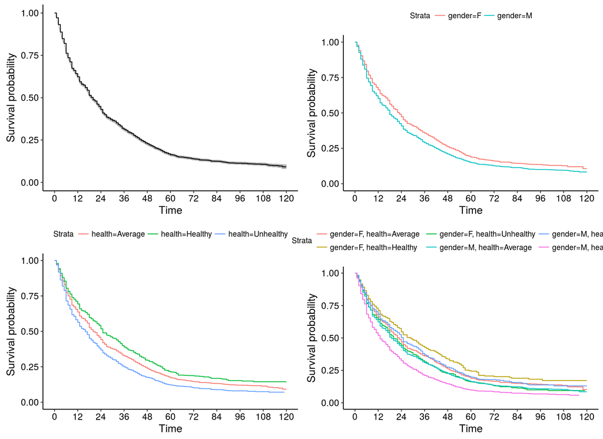

```r
nosplit_km <- survfit(Surv(time,fail) ~ 1, data = data_dt)
plot_1     <- ggsurvplot(nosplit_km, censor = FALSE, size = 0.5, break.time.by = 12)

gender_km <- survfit(Surv(time,fail) ~ gender, data = data_dt)
plot_2    <- ggsurvplot(gender_km, censor = FALSE, size = 0.5, break.time.by = 12)

health_km <- survfit(Surv(time,fail) ~ health, data = data_dt)
plot_3    <- ggsurvplot(health_km, censor = FALSE, size = 0.5, break.time.by = 12)

both_km <- survfit(Surv(time,fail) ~ gender + health, data = data_dt)
plot_4  <- ggsurvplot(both_km, censor = FALSE, size = 0.5, break.time.by = 12)


plot_grid(plot_1$plot, plot_2$plot, plot_3$plot, plot_4$plot, ncol = 2)
```

# 3 Write to Disk

```r
write_feather(data_dt, path = 'data/sample_data.feather')

saveRDS(data_dt, 'km_dashboard/data_dt.rds', compress = 'xz')
```